# Assignment2

Jasmine

March 3, 2017

# Problem 1: load and explore the data

```
##
## ==================================================
## Statistic   N     Mean    St. Dev.    Min    Max
## --------------------------------------------------
## model.id  2,217  276.210   160.183     1     557
## firm.id   2,217  13.744     6.259      1      26
## cdid      2,217  11.540     5.741      1      20
## id        2,217 2,559.081 1,517.647   129   5,592
## price     2,217  11.761     8.644    3.393  68.596
## mpd       2,217   2.085     0.698    0.846  6.437
## air       2,217   0.242     0.428      0      1
## mpg       2,217   2.100     0.581    0.913  5.300
## space     2,217   1.310     0.238    0.756  1.888
## hpwt      2,217   0.394     0.097    0.170  0.948
## trend     2,217 1,980.540   5.741    1,970  1,989
## share     2,217   0.001     0.001   0.00000 0.009
## outshr    2,217   0.893     0.014    0.871  0.919
## y         2,217  -0.000     1.382   -6.498  3.029
## --------------------------------------------------
```

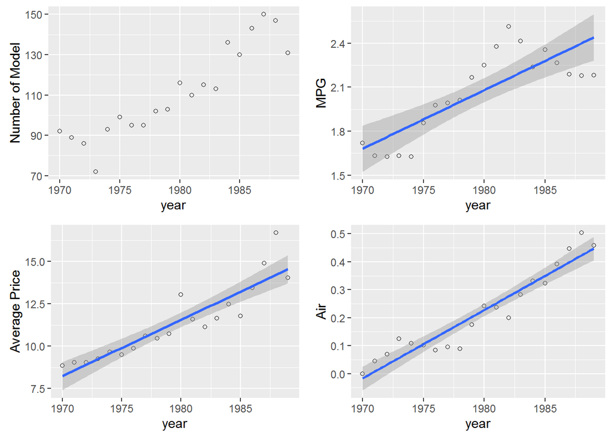

```
##
## ================================================
##    year  No.model Price   MPG   Air  Spce  HP/Wt
## ------------------------------------------------
## 1  1,970    92    8.856  1.720   0   1.442 0.510
## 2  1,971    89    9.042  1.633 0.045 1.458 0.407
## 3  1,972    86    9.045  1.625 0.070 1.466 0.385
## 4  1,973    72    9.254  1.633 0.125 1.426 0.368
## 5  1,974    93    9.641  1.627 0.108 1.416 0.354
## 6  1,975    99    9.490  1.856 0.101 1.379 0.354
## 7  1,976    95    9.864  1.978 0.084 1.358 0.356
## 8  1,977    95    10.602 1.993 0.095 1.344 0.363
## 9  1,978   102    10.451 2.011 0.088 1.307 0.366
## 10 1,979   103    10.726 2.167 0.175 1.296 0.363
## 11 1,980   116    13.035 2.250 0.241 1.301 0.362
## 12 1,981   110    11.591 2.377 0.236 1.283 0.358
## 13 1,982   115    11.140 2.515 0.200 1.273 0.358
## 14 1,983   113    11.647 2.415 0.283 1.264 0.387
## 15 1,984   136    12.476 2.239 0.331 1.246 0.390
## 16 1,985   130    11.782 2.355 0.323 1.233 0.398
## 17 1,986   143    13.436 2.265 0.392 1.231 0.414
## 18 1,987   150    14.885 2.188 0.447 1.246 0.432
## 19 1,988   147    16.690 2.179 0.503 1.247 0.453
## 20 1,989   131    14.038 2.182 0.458 1.255 0.449
## ------------------------------------------------
```

## Problem 2: Logit Demand

```
##
## ==================================================================
##                                        Dependent variable:
##                                 ----------------------------------
##                                            y            log(price)
##                                    OLS     instrumental    OLS
##                                              variable
##                                    (1)         (2)         (3)
## ------------------------------------------------------------------
## price                           -0.089***   -0.158***
##                                  (0.004)     (0.009)
##
## hpwt                              -0.124     1.866***    1.443***
##                                  (0.277)     (0.363)     (0.077)
##
## air                               -0.034     0.733***    0.673***
##                                  (0.073)     (0.112)     (0.018)
##
## mpd                              0.265***    0.127***
##                                  (0.043)     (0.048)
##
## mpg                                                     -0.193***
##                                                          (0.020)
##
## trend                                                    0.012***
##                                                          (0.001)
##
## space                            2.342***    2.268***    0.127***
##                                  (0.125)     (0.134)     (0.042)
##
## Constant                        -2.521***   -2.291***    1.678***
##                                  (0.253)     (0.270)     (0.102)
##
## ------------------------------------------------------------------
## Observations                      2,217       2,217       2,217
## R2                                0.387       0.305       0.669
## Adjusted R2                       0.386       0.303       0.669
## Residual Std. Error (df = 2211)   1.083       1.153       0.307
## F Statistic (df = 5; 2211)      279.243***              895.193***
## ==================================================================
## Note:                                  *p<0.1; **p<0.05; ***p<0.01
```

```
## [1] 1502
```

There are over a half observations with inelastic demand. This is inconsistent with the profit maximization assumptions.

## Problem 3: Shares and delta

The test code for share.fn and delta.fn.

```
##        V1
##  Min.   :2.804e-06
##  1st Qu.:3.971e-06
##  Median :4.338e-06
##  Mean   :4.377e-06
##  3rd Qu.:5.012e-06
##  Max.   :5.235e-06
```

Check the derivative function is correct.

```
##       Min.    1st Qu.     Median       Mean    3rd Qu.       Max.
## -7.388e-13 -1.126e-14  2.789e-15  4.299e-14  2.617e-14  1.487e-12
```

```
##       Min.    1st Qu.     Median       Mean    3rd Qu.       Max.
## -2.584e-04 -2.569e-08  0.000e+00  0.000e+00  2.569e-08  2.584e-04
```

## Problem 4: code optimization

The inline functions and apply procedure takes most of the time. Share.fun first record all the values for each y draw, then take average. This apply function takes a lot of time, so instead of recording every draw of y, I sum up the share, and devide by S at the end. This is a similar case in function dshare.dp. The time is shortened by 90%. However, on the cost side, the parameters does not agree with the paper in sign. I doubt it is due to the construction of IV is not completely valid.

## Problem 5: estimation

```
##          [,1]
## [1,] 1.031081
```

```
## iteration: 1
##  x = ( 43.501000, 3.612000, 4.628000, 1.818000, 1.050000, 2.056000 )
##  f(x) = 1.031081
## iteration: 2
##  x = ( 72.864175, 3.612000, 4.628000, 1.818000, 1.050000, 2.056000 )
```

```
##  f(x) = 2.457815
## iteration: 3
##  x = ( 43.501000, 6.050100, 4.628000, 1.818000, 1.050000, 2.056000 )
##  f(x) = 1.229745
## iteration: 4
##  x = ( 43.501000, 3.612000, 7.751900, 1.818000, 1.050000, 2.056000 )
##  f(x) = 1.108936
## iteration: 5
##  x = ( 43.501000, 3.612000, 4.628000, 3.045150, 1.050000, 2.056000 )
##  f(x) = 1.097810
## iteration: 6
##  x = ( 43.501000, 3.612000, 4.628000, 1.818000, 1.758750, 2.056000 )
##  f(x) = 1.162734
## iteration: 7
##  x = ( 43.501000, 3.612000, 4.628000, 1.818000, 1.050000, 3.443800 )
##  f(x) = 1.208771
## iteration: 8
##  x = ( 14.137825, 3.612000, 4.628000, 1.818000, 1.050000, 2.056000 )
##  f(x) = 0.415877
## iteration: 9
##  x = ( 43.501000, 1.173900, 4.628000, 1.818000, 1.050000, 2.056000 )
##  f(x) = 0.907698
## iteration: 10
##  x = ( 43.501000, 3.612000, 1.504100, 1.818000, 1.050000, 2.056000 )
##  f(x) = 0.973504
## iteration: 11
##  x = ( 43.501000, 3.612000, 4.628000, 0.590850, 1.050000, 2.056000 )
##  f(x) = 0.993420
## iteration: 12
##  x = ( 43.501000, 3.612000, 4.628000, 1.818000, 0.341250, 2.056000 )
##  f(x) = 0.963296
## iteration: 13
##  x = ( 43.501000, 3.612000, 4.628000, 1.818000, 1.050000, 0.668200 )
##  f(x) = 0.915315
## iteration: 14
##  x = ( 4.350100, 2.174826, 3.810084, 1.572449, 0.788256, 1.300389 )
##  f(x) = 0.142017
## iteration: 15
##  x = ( 4.350100, 0.361200, 0.462800, 0.511930, 0.105000, 0.205600 )
##  f(x) = 0.074706
```

[output cut: 102 more lines]

```
## iteration: 50
##  x = ( 6.380309, 0.361200, 0.462800, 0.181923, 0.105001, 0.205601 )
##  f(x) = 0.072530
## iteration: 51
##  x = ( 6.379020, 0.361200, 0.462800, 0.181800, 0.105000, 0.205725 )
##  f(x) = 0.072530
## iteration: 52
##  x = ( 6.382657, 0.361200, 0.462800, 0.181800, 0.105000, 0.205683 )
##  f(x) = 0.072530
## iteration: 53
##  x = ( 6.380309, 0.361433, 0.462800, 0.181836, 0.105000, 0.205604 )
##  f(x) = 0.072530
## iteration: 54
##  x = ( 6.379114, 0.361200, 0.462800, 0.181800, 0.105000, 0.205600 )
##  f(x) = 0.072529
```

```
##
## =====================
## alpha          6.379
## sigma.constant 0.361
## sigma.hpwt     0.463
## sigma.air      0.182
## sigma.mpd      0.105
## sigma.space    0.206
## beta.constant  -9.542
## beta.hpwt      1.072
## beta.air       0.550
## beta.mpd       0.267
## beta.space     2.652
## gamma.constant 3.173
## gamma.hpwt     0.435
## gamma.air      0.573
## gamma.mpd      -0.355
## gamma.space    0.123
## gamma.trend    0.010
## ---------------------
```

I tried to use weight matrix as the outer product of instruments. However, this result seems to be even worse. The scale of alpha is far away from the estimation.

```
##          [,1]
## [1,] 7080.993
```

```
##
## ======================
## alpha          31.242
## sigma.constant  2.632
## sigma.hpwt      4.538
## sigma.air       0.182
## sigma.mpd       0.939
## sigma.space     0.659
## beta.constant  -11.531
## beta.hpwt       5.179
## beta.air        6.889
## beta.mpd       -0.162
## beta.space      5.323
## gamma.constant  1.941
## gamma.hpwt     -0.003
## gamma.air       1.368
## gamma.mpd       0.508
## gamma.space     0.355
## gamma.trend    -0.021
## ----------------------
```

Compare to table IV in the BLP paper, the sign mostly agrees for beta. This implies that the demand side is correctly estimated. However, the supply side is not similar to the paper. The signs of gamma does not aggree.

## Problem 6:

The standard error for betas and gammas are calculated in previous question. The code is added to the moment function. Since the estimation is using GMM, the variance matrix can be obtained using analytical form. My standard error for beta and gamma does not deviate too much from the BLP paper.

For the variance of alpha and sigmas, using the fact that betas and gammas are function of alpha_sigmas. By applying the delta method, we can then solve for the variance.

```
##
## ===============================
##                estimate   sd
## -------------------------------
## alpha           31.242   0.028
## sigma.constant  2.632   0.0003
## sigma.hpwt      4.538   0.0001
## sigma.air       0.182   0.00001
## sigma.mpd       0.939    0.001
## sigma.space     0.659    0.001
## beta.constant  -11.531   1.262
## beta.hpwt       5.179    4.447
## beta.air        6.889    0.594
## beta.mpd        -0.162   0.246
## beta.space      5.323    0.675
## gamma.constant  1.941    0.159
## gamma.hpwt      -0.003   0.118
## gamma.air       1.368    0.137
## gamma.mpd       0.508    0.171
## gamma.space     0.355    0.181
## gamma.trend     -0.021   0.005
## -------------------------------
```